# Final Project Analysis : R Scripts

Antara Saha

2022-10-17

# **INTRODUCTION**:

For my final project, I will be performing analysis to find the relation between Homeschooling with vaccination status, race & education attainment.

For this analysis, I will use the Household Pulse Survey data from Phase 3.4 and Phase 3.5, available here:

- [Phase 3.5 PUF Releases](https://www.census.gov/programs-surveys/household-pulse-survey/datasets.html#phase3.5)
- [Phase 3.4 PUF Releases](https://www.census.gov/programs-surveys/household-pulse-survey/datasets.html#phase3.4)

### **STEP 1: LOAD DATA INTO R**

```r
# Load Data into R
library(tidyverse)
library(dplyr)
library(knitr)
library(lmtest)
library(ggpubr)
library(ggthemes)

inp_fl <- list.files(pattern=".csv")

tmp_dt_5_11 <- data.frame(matrix(ncol = 5, nrow = 0))
colnames(tmp_dt_5_11) <- c('RRACE','EEDUC','ENRHMSCHK',
                           'KIDS_5_11Y','KIDDOSESRV_5_11Y')

tmp_dt_12_17 <- data.frame(matrix(ncol = 5, nrow = 0))
colnames(tmp_dt_12_17) <- c('RRACE','EEDUC','ENRHMSCHK',
                            'KIDS_12_17Y','KIDDOSESRV_12_17Y')

#Load file in R
for (i in 1:length(inp_fl))
{
  inp_dt <- data.frame(read.csv(inp_fl[i], header = TRUE, stringsAsFactors = FALSE,
                                na.strings = c("-88","-99")))

  if(i<=3){
    inp_dt_5_11 <- inp_dt%>%
      select(RRACE,EEDUC,ENRHMSCHK,KIDS_5_11Y,KIDDOSES_5_11Y)%>%
      filter(KIDS_5_11Y==1)%>%
      mutate(HMSCH = ifelse(ENRHMSCHK ==1,1,0))%>%
      rename(KIDDOSESRV_5_11Y=KIDDOSES_5_11Y)

    inp_dt_12_17 <- inp_dt%>%
      select(RRACE,EEDUC,ENRHMSCHK,KIDS_12_17Y,KIDDOSES_12_17Y)%>%
      filter(KIDS_12_17Y==1)%>%
      mutate(HMSCH = ifelse(ENRHMSCHK ==1,1,0))%>%
      rename(KIDDOSESRV_12_17Y=KIDDOSES_12_17Y)
  }
  else{
    inp_dt_5_11 <- inp_dt%>%
      select(RRACE,EEDUC,ENRHMSCHK,KIDS_5_11Y,KIDDOSESRV_5_11Y)%>%
      filter(KIDS_5_11Y==1)%>%
      mutate(HMSCH = ifelse(ENRHMSCHK ==1,1,0))

    inp_dt_12_17 <- inp_dt%>%
      select(RRACE,EEDUC,ENRHMSCHK,KIDS_12_17Y,KIDDOSESRV_12_17Y)%>%
      filter(KIDS_12_17Y==1)%>%
      mutate(HMSCH = ifelse(ENRHMSCHK ==1,1,0))

  }

  tmp_dt_5_11 <- bind_rows(tmp_dt_5_11, inp_dt_5_11)
  tmp_dt_12_17 <- bind_rows(tmp_dt_12_17, inp_dt_12_17)

  inp_dt <- data.frame(NULL)
}

# Remove records where the Vaccination Status for kids is anything other than Yes or No.

fnl_dt_5_11 <-
  tmp_dt_5_11%>%
  filter(KIDDOSESRV_5_11Y !=3&!is.na(KIDDOSESRV_5_11Y))

fnl_dt_12_17 <-
  tmp_dt_12_17%>%
  filter(KIDDOSESRV_12_17Y !=3&!is.na(KIDDOSESRV_12_17Y))

fnl_dt_5_11$HMSCH[is.na(fnl_dt_5_11$HMSCH)] <- 0
fnl_dt_12_17$HMSCH[is.na(fnl_dt_12_17$HMSCH)] <- 0
```

### **STEP 2: CREATE FACTORS**

```r
# Convert Vaccination Status, Race, and Education attainment into factors.

# RACE
fnl_dt_5_11$RRACE <-
  factor(fnl_dt_5_11$RRACE,labels = c("White", "Black", "Asian","Other"))

fnl_dt_12_17$RRACE <-
  factor(fnl_dt_12_17$RRACE,labels = c("White", "Black", "Asian","Other"))

# EDUCATION ATTAINMENT
fnl_dt_5_11$EEDUC <- ifelse(fnl_dt_5_11$EEDUC <=4 ,"Less Educated","Well Educated")
fnl_dt_12_17$EEDUC <- ifelse(fnl_dt_12_17$EEDUC <=4 ,"Less Educated","Well Educated")

fnl_dt_5_11$EEDUC <- as.factor(fnl_dt_5_11$EEDUC)
fnl_dt_12_17$EEDUC <- as.factor(fnl_dt_12_17$EEDUC)

# VACCINATION STATUS
fnl_dt_5_11$KIDDOSESRV_5_11Y <-
  factor(fnl_dt_5_11$KIDDOSESRV_5_11Y,labels = c("Vaccinated","Not_Vaccinated"))

fnl_dt_12_17$KIDDOSESRV_12_17Y <-
  factor(fnl_dt_12_17$KIDDOSESRV_12_17Y,labels = c("Vaccinated","Not_Vaccinated"))
```

Final Data Tables after data cleansing for age groups 5-11 and 12-17 years old.

```r
kable(head(fnl_dt_5_11),caption = "**Table 1: Final Data Table for Age Group 5-11 Years Old**")
```

**Table 1: Final Data Table for Age Group 5-11 Years Old**

| RRACE | EEDUC | ENRHMSCHK | KIDS_5_11Y | KIDDOSESRV_5_11Y | HMSCH |
| --- | --- | --- | --- | --- | --- |
| White | Less Educated | NA | 1 | Not_Vaccinated | 0 |
| Other | Less Educated | NA | 1 | Vaccinated | 0 |
| White | Well Educated | NA | 1 | Not_Vaccinated | 0 |
| White | Less Educated | NA | 1 | Not_Vaccinated | 0 |
| Other | Less Educated | NA | 1 | Vaccinated | 0 |
| White | Less Educated | NA | 1 | Vaccinated | 0 |

```r
kable(head(fnl_dt_12_17),caption = "**Table 2: Final Data Table for Age Group 12-17 Years Old**")
```

**Table 2: Final Data Table for Age Group 12-17 Years Old**

| RRACE | EEDUC | ENRHMSCHK | KIDS_12_17Y | KIDDOSESRV_12_17Y | HMSCH |
| --- | --- | --- | --- | --- | --- |
| White | Well Educated | NA | 1 | Not_Vaccinated | 0 |
| White | Well Educated | 1 | 1 | Vaccinated | 1 |
| Asian | Less Educated | NA | 1 | Vaccinated | 0 |
| White | Well Educated | NA | 1 | Vaccinated | 0 |
| White | Less Educated | NA | 1 | Vaccinated | 0 |
| White | Well Educated | NA | 1 | Vaccinated | 0 |

# **FOR KIDS AGE GROUP 5-11 YEARS OLD**

### **STEP 3: DESCRIPTIVE STATISTICS**

Proportion of kids Homeschooling based on the demographic factors.

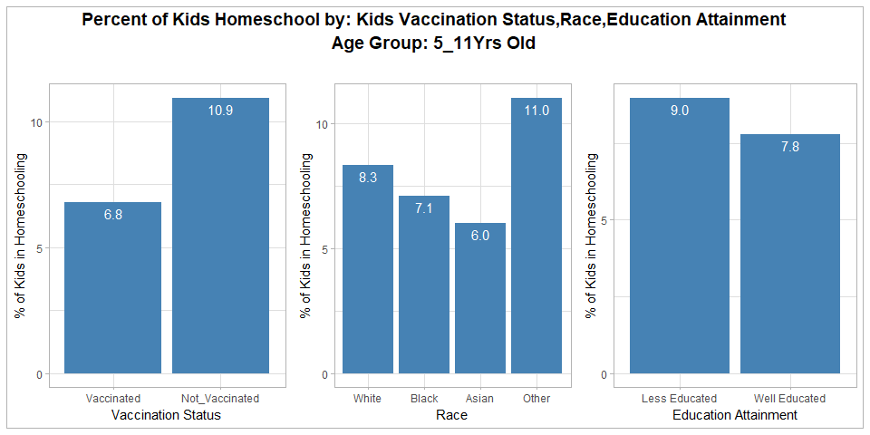

```r
# For Kids Age Group : 5_11 Yrs Old

# Plot Percent of Kids Homeschooling Vs Vaccination Status
plot1 <- fnl_dt_5_11%>%
  group_by(KIDDOSESRV_5_11Y,HMSCH)%>%
  summarise(count = n())%>%
  mutate(pct = (count/sum(count))*100)%>%
  filter(HMSCH == 1)%>%
  ggplot(aes(KIDDOSESRV_5_11Y, pct))+
  geom_bar(stat = "identity", position = 'dodge', fill="steelblue")+
  scale_y_continuous(breaks = seq(0,20,5))+
  labs(y = "% of Kids in Homeschooling", x = "Vaccination Status")+
  geom_text(aes(label = formatC(pct, digits = 1, format = "f")),
            colour = "white", size = 4, vjust = 1.5)+
  theme_light()

# Plot Percent of Kids Homeschooling Vs Race
plot2 <- fnl_dt_5_11%>%
  group_by(RRACE,HMSCH)%>%
  summarise(count = n())%>%
  mutate(pct = (count/sum(count))*100)%>%
  filter(HMSCH == 1)%>%
  ggplot(aes(RRACE, pct))+
  geom_bar(stat = "identity", position = 'dodge', fill="steelblue")+
  scale_y_continuous(breaks = seq(0,20,5))+
  labs(y = "% of Kids in Homeschooling", x = "Race")+
  geom_text(aes(label = formatC(pct, digits = 1, format = "f")),
            colour = "white", size = 4, vjust = 1.5)+
  theme_light()

# Plot Percent of Kids Homeschooling Vs Education Attainment
plot3 <- fnl_dt_5_11%>%
  group_by(EEDUC,HMSCH)%>%
  summarise(count = n())%>%
  mutate(pct = (count/sum(count))*100)%>%
  filter(HMSCH == 1)%>%
  ggplot(aes(EEDUC, pct))+
  geom_bar(stat = "identity", position = 'dodge', fill="steelblue")+
  scale_y_continuous(breaks = seq(0,20,5))+
  labs(y = "% of Kids in Homeschooling", x = "Education Attainment")+
  geom_text(aes(label = formatC(pct, digits = 1, format = "f")),
            colour = "white", size = 4, vjust = 1.5)+
  theme_light()

# Combining all plot into one
combined_plot_5_11 <- ggarrange(plot1, plot2, plot3, nrow = 1, ncol = 3,
                                common.legend = TRUE,legend="bottom")
annotate_figure(combined_plot_5_11,
                top = text_grob("Percent of Kids Homeschool by: Kids Vaccination Status,Race,Education Attainment\nAge Group: 5_11Yrs Old\n",
                                color = "black", face = "bold", size = 14))+
  theme_light()
```

### **STEP 4: DISPROPORTIONALITY INDICES**

Determine the disproportional indices for the % of children who are Homeschooling based on the demographic characteristics

```r
# Define Function to calculate Disproportionality Indices
disp <- function(cats,condition,pop)
  {
  dispnum <- condition/sum(condition)
  dispdenom <- pop/sum(pop)
  disp <- dispnum/dispdenom
  return(data.frame(category=cats, share_condition=dispnum,
                    share_population=dispdenom, disproportionality=disp))
}
```

```r
# Disproportionality Indices for kids Homeschooling of age 5-11 yrs old by Vaccination Status
fnl_dt_5_11_summary <- fnl_dt_5_11%>%
  group_by(KIDDOSESRV_5_11Y)%>%
  summarise(hh_kids = n(),
            hh_kids_homeschool = length(HMSCH[HMSCH == 1]),
            hh_kids_not_homeschool = length(HMSCH[HMSCH == 0]))

disp_ind_5_11 <- disp(fnl_dt_5_11_summary$KIDDOSESRV_5_11Y,fnl_dt_5_11_summary$hh_kids_homeschool,fnl_dt_5_11_summary$hh_kids)

# Rank them from highest to lowest
disp_ind_5_11$Rank <- rank(-disp_ind_5_11$disproportionality)

kable(disp_ind_5_11[order(disp_ind_5_11$Rank, decreasing = FALSE), ],
      caption = "**Table 3: Disproportionality Indices for kids Homeschooling of age 5-11 yrs old by Vaccination Status**")
```

**Table 3: Disproportionality Indices for kids Homeschooling of age 5-11 yrs old by Vaccination Status**

|  | category | share_condition | share_population | disproportionality | Rank |
| --- | --- | --- | --- | --- | --- |
| 2 | Not_Vaccinated | 0.4501856 | 0.3364678 | 1.3379752 | 1 |
| 1 | Vaccinated | 0.5498144 | 0.6635322 | 0.8286176 | 2 |

```r
# Disproportionality Indices for kids Homeschooling of age 5-11 yrs old by Race
fnl_dt_5_11_summary <- fnl_dt_5_11%>%
  group_by(RRACE)%>%
  summarise(hh_kids = n(),
            hh_kids_homeschool = length(HMSCH[HMSCH == 1]),
            hh_kids_not_homeschool = length(HMSCH[HMSCH == 0]))

disp_ind_5_11 <- disp(fnl_dt_5_11_summary$RRACE,fnl_dt_5_11_summary$hh_kids_homeschool,fnl_dt_5_11_summary$hh_kids)

# Rank them from highest to lowest
disp_ind_5_11$Rank <- rank(-disp_ind_5_11$disproportionality)

kable(disp_ind_5_11[order(disp_ind_5_11$Rank, decreasing = FALSE), ],
      caption = "**Table 4: Disproportionality Indices for kids Homeschooling of age 5-11 yrs old by Race**")
```

**Table 4: Disproportionality Indices for kids Homeschooling of age 5-11 yrs old by Race**

|  | category | share_condition | share_population | disproportionality | Rank |
| --- | --- | --- | --- | --- | --- |
| 4 | Other | 0.0850699 | 0.0631402 | 1.3473180 | 1 |
| 1 | White | 0.7687696 | 0.7560025 | 1.0168877 | 2 |
| 2 | Black | 0.0876392 | 0.1013137 | 0.8650280 | 3 |
| 3 | Asian | 0.0585213 | 0.0795436 | 0.7357131 | 4 |

```r
# Disproportionality Indices for kids Homeschooling of age 5-11 yrs old by Education Attainment
fnl_dt_5_11_summary <- fnl_dt_5_11%>%
  group_by(EEDUC)%>%
  summarise(hh_kids = n(),
            hh_kids_homeschool = length(HMSCH[HMSCH == 1]),
            hh_kids_not_homeschool = length(HMSCH[HMSCH == 0]))

disp_ind_5_11 <- disp(fnl_dt_5_11_summary$EEDUC,fnl_dt_5_11_summary$hh_kids_homeschool,fnl_dt_5_11_summary$hh_kids)

# Rank them from highest to lowest
disp_ind_5_11$Rank <- rank(-disp_ind_5_11$disproportionality)

kable(disp_ind_5_11[order(disp_ind_5_11$Rank, decreasing = FALSE), ],
      caption = "**Table 5: Disproportionality Indices for kids Homeschooling of age 5-11 yrs old by Education Attainment**")
```

**Table 5: Disproportionality Indices for kids Homeschooling of age 5-11 yrs old by Education Attainment**

| category | share_condition | share_population | disproportionality | Rank |
| --- | --- | --- | --- | --- |
| Less Educated | 0.3596917 | 0.3273678 | 1.0987389 | 1 |
| Well Educated | 0.6403083 | 0.6726322 | 0.9519441 | 2 |

### **STEP 5: MULTIVARIATE REGRESSION & ODDS RATIO**

Conduct a regression to test the hypothesis that the association of the dependent variable with independent variables is statistically significant. Also,evaluate the odds of being Homeschooling for above stated demographic factors.

**NOTE:** For the purposes of this analysis, I’ll use the reference categories of

- “White” for race
- “Well-Educated” for educational attainment
- “Vaccinated” for Vaccination Status

```r
mdl_0_5_11 <- glm(HMSCH ~1, data = fnl_dt_5_11)
mdl_multi_5_11 <- glm(HMSCH ~ KIDDOSESRV_5_11Y+
                   relevel(RRACE,1)+
                   relevel(EEDUC,2),
                 data = fnl_dt_5_11,family = "binomial")
summary(mdl_multi_5_11)
```

```
##
## Call:
## glm(formula = HMSCH ~ KIDDOSESRV_5_11Y + relevel(RRACE, 1) +
##     relevel(EEDUC, 2), family = "binomial", data = fnl_dt_5_11)
##
## Deviance Residuals:
##     Min       1Q   Median       3Q      Max
## -0.5559  -0.4370  -0.3775  -0.3775   2.4072
##
## Coefficients:
##                                Estimate Std. Error z value Pr(>|z|)
## (Intercept)                    -2.60563    0.02725 -95.604  < 2e-16 ***
## KIDDOSESRV_5_11YNot_Vaccinated  0.51165    0.03696  13.842  < 2e-16 ***
## relevel(RRACE, 1)Black         -0.22835    0.06302  -3.624  0.00029 ***
## relevel(RRACE, 1)Asian         -0.23500    0.07548  -3.113  0.00185 **
## relevel(RRACE, 1)Other          0.28796    0.06516   4.420 9.89e-06 ***
## relevel(EEDUC, 2)Less Educated  0.01689    0.03846   0.439  0.66056
## ---
## Signif. codes:  0 '***' 0.001 '**' 0.01 '*' 0.05 '.' 0.1 ' ' 1
##
## (Dispersion parameter for binomial family taken to be 1)
##
##     Null deviance: 24256  on 42856  degrees of freedom
## Residual deviance: 23997  on 42851  degrees of freedom
## AIC: 24009
##
## Number of Fisher Scoring iterations: 5
```

```r
exp(coef(mdl_multi_5_11))
```

```
##                    (Intercept) KIDDOSESRV_5_11YNot_Vaccinated
##                     0.07385628                     1.66804893
##         relevel(RRACE, 1)Black         relevel(RRACE, 1)Asian
##                     0.79584268                     0.79056755
##         relevel(RRACE, 1)Other relevel(EEDUC, 2)Less Educated
##                     1.33369855                     1.01703480
```

```r
lrtest(mdl_0_5_11,mdl_multi_5_11)
```

```
## Likelihood ratio test
##
## Model 1: HMSCH ~ 1
## Model 2: HMSCH ~ KIDDOSESRV_5_11Y + relevel(RRACE, 1) + relevel(EEDUC,
##     2)
##   #Df   LogLik Df Chisq Pr(>Chisq)
## 1   2  -5321.9
## 2   6 -11998.5  4 13353  < 2.2e-16 ***
## ---
## Signif. codes:  0 '***' 0.001 '**' 0.01 '*' 0.05 '.' 0.1 ' ' 1
```

# **FOR KIDS AGE GROUP 12-17 YEARS OLD**

### **STEP 3: DESCRIPTIVE STATISTICS**

Proportion of kids Homeschooling based on the demographic factors.

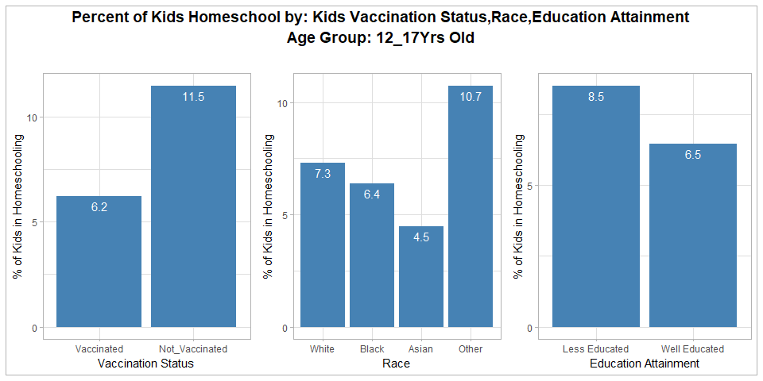

```r
# For Kids Age Group :12-17 Yrs Old
# Plot Percent of Kids Homeschooling Vs Vaccination Status
plot1 <- fnl_dt_12_17%>%
  group_by(KIDDOSESRV_12_17Y,HMSCH)%>%
  summarise(count = n())%>%
  mutate(pct = (count/sum(count))*100)%>%
  filter(HMSCH == 1)%>%
  ggplot(aes(KIDDOSESRV_12_17Y, pct))+
  geom_bar(stat = "identity", position = 'dodge', fill="steelblue")+
  scale_y_continuous(breaks = seq(0,20,5))+
  labs(y = "% of Kids in Homeschooling", x = "Vaccination Status")+
  geom_text(aes(label = formatC(pct, digits = 1, format = "f")),
            colour = "white", size = 4, vjust = 1.5)+
  theme_light()

# Plot Percent of Kids Homeschooling Vs Race
plot2 <- fnl_dt_12_17%>%
  group_by(RRACE,HMSCH)%>%
  summarise(count = n())%>%
  mutate(pct = (count/sum(count))*100)%>%
  filter(HMSCH == 1)%>%
  ggplot(aes(RRACE, pct))+
  geom_bar(stat = "identity", position = 'dodge', fill="steelblue")+
  scale_y_continuous(breaks = seq(0,20,5))+
  labs(y = "% of Kids in Homeschooling", x = "Race")+
  geom_text(aes(label = formatC(pct, digits = 1, format = "f")),
            colour = "white", size = 4, vjust = 1.5)+
  theme_light()

# Plot Percent of Kids Homeschooling Vs Education Attainment
plot3 <- fnl_dt_12_17%>%
  group_by(EEDUC,HMSCH)%>%
  summarise(count = n())%>%
  mutate(pct = (count/sum(count))*100)%>%
  filter(HMSCH == 1)%>%
  ggplot(aes(EEDUC, pct))+
  geom_bar(stat = "identity", position = 'dodge', fill="steelblue")+
  scale_y_continuous(breaks = seq(0,20,5))+
  labs(y = "% of Kids in Homeschooling", x = "Education Attainment")+
  geom_text(aes(label = formatC(pct, digits = 1, format = "f")),
            colour = "white", size = 4, vjust = 1.5)+
  theme_light()

# Combining all plot into one
combined_plot_12_17 <- ggarrange(plot1, plot2, plot3, nrow = 1, ncol = 3,
                                common.legend = TRUE,legend="bottom")
annotate_figure(combined_plot_12_17,
                top = text_grob("Percent of Kids Homeschool by: Kids Vaccination Status,Race,Education Attainment\nAge Group: 12_17Yrs Old\n",
                                color = "black", face = "bold", size = 14))+
  theme_light()
```

### **STEP 4: DISPROPORTIONALITY INDICES**

Determine the disproportional indices for the % of children who are homeschooled based on the demographic characteristics

```r
# Disproportionality Indices for kids Homeschooling of age 12-17 yrs old by Vaccination Status
fnl_dt_12_17_summary <- fnl_dt_12_17%>%
  group_by(KIDDOSESRV_12_17Y)%>%
  summarise(hh_kids = n(),
            hh_kids_homeschool = length(HMSCH[HMSCH == 1]),
            hh_kids_not_homeschool = length(HMSCH[HMSCH == 0]))

disp_ind_12_17 <- disp(fnl_dt_12_17_summary$KIDDOSESRV_12_17Y,fnl_dt_12_17_summary$hh_kids_homeschool,fnl_dt_12_17_summary$hh_kids)

# Rank them from highest to lowest
disp_ind_12_17$Rank <- rank(-disp_ind_12_17$disproportionality)

kable(disp_ind_12_17[order(disp_ind_12_17$Rank, decreasing = FALSE), ],
      caption = "**Table 6: Disproportionality Indices for kids Homeschooling of age 12-17 yrs old by Vaccination Status**")
```

**Table 6: Disproportionality Indices for kids Homeschooling of age 12-17 yrs old by Vaccination Status**

|  | category | share_condition | share_population | disproportionality | Rank |
| --- | --- | --- | --- | --- | --- |
| 2 | Not_Vaccinated | 0.3060109 | 0.1923061 | 1.5912700 | 1 |
| 1 | Vaccinated | 0.6939891 | 0.8076939 | 0.8592229 | 2 |

```r
# Disproportionality Indices for kids Homeschooling of age 12-17 yrs old by Race
fnl_dt_12_17_summary <- fnl_dt_12_17%>%
  group_by(RRACE)%>%
  summarise(hh_kids = n(),
            hh_kids_homeschool = length(HMSCH[HMSCH == 1]),
            hh_kids_not_homeschool = length(HMSCH[HMSCH == 0]))

disp_ind_12_17 <- disp(fnl_dt_12_17_summary$RRACE,fnl_dt_12_17_summary$hh_kids_homeschool,fnl_dt_12_17_summary$hh_kids)

# Rank them from highest to lowest
disp_ind_12_17$Rank <- rank(-disp_ind_12_17$disproportionality)

kable(disp_ind_12_17[order(disp_ind_12_17$Rank, decreasing = FALSE), ],
      caption = "**Table 7: Disproportionality Indices for kids Homeschooling of age 12-17 yrs old by Race**")
```

**Table 7: Disproportionality Indices for kids Homeschooling of age 12-17 yrs old by Race**

|  | category | share_condition | share_population | disproportionality | Rank |
| --- | --- | --- | --- | --- | --- |
| 4 | Other | 0.0926086 | 0.0622613 | 1.4874190 | 1 |
| 1 | White | 0.7679034 | 0.7593215 | 1.0113020 | 2 |
| 2 | Black | 0.0960598 | 0.1085368 | 0.8850439 | 3 |
| 3 | Asian | 0.0434282 | 0.0698804 | 0.6214651 | 4 |

```r
# Disproportionality Indices for kids Homeschooling of age 12-17 yrs old by Education Attainment
fnl_dt_12_17_summary <- fnl_dt_12_17%>%
  group_by(EEDUC)%>%
  summarise(hh_kids = n(),
            hh_kids_homeschool = length(HMSCH[HMSCH == 1]),
            hh_kids_not_homeschool = length(HMSCH[HMSCH == 0]))

disp_ind_12_17 <- disp(fnl_dt_12_17_summary$EEDUC,fnl_dt_12_17_summary$hh_kids_homeschool,fnl_dt_12_17_summary$hh_kids)

# Rank them from highest to lowest
disp_ind_12_17$Rank <- rank(-disp_ind_12_17$disproportionality)

kable(disp_ind_12_17[order(disp_ind_12_17$Rank, decreasing = FALSE), ],
      caption = "**Table 8: Disproportionality Indices for kids Homeschooling of age 12-17 yrs old by Education Attainment**")
```

**Table 8: Disproportionality Indices for kids Homeschooling of age 12-17 yrs old by Education Attainment**

| category | share_condition | share_population | disproportionality | Rank |
| --- | --- | --- | --- | --- |
| Less Educated | 0.4368709 | 0.3707648 | 1.1782964 | 1 |
| Well Educated | 0.5631291 | 0.6292352 | 0.8949422 | 2 |

### **STEP 5: MULTIVARIATE REGRESSION & ODDS RATIO**

Conduct a regression to test the hypothesis that the association of the dependent variable with independent variables is statistically significant.Also,evaluate the odds of being Homeschooling for above stated demographic factors.

**NOTE:** For the purposes of this analysis, I’ll use the reference categories of

- “White” for race
- “Well-Educated” for educational attainment
- “Vaccinated” for Vaccination Status

```r
mdl_0_12_17 <- glm(HMSCH ~1, data = fnl_dt_12_17)
mdl_multi_12_17 <- glm(HMSCH ~ KIDDOSESRV_12_17Y+
                   relevel(RRACE,1)+
                   relevel(EEDUC,2),
                 data = fnl_dt_12_17,family = "binomial")
summary(mdl_multi_12_17)
```

```
##
## Call:
## glm(formula = HMSCH ~ KIDDOSESRV_12_17Y + relevel(RRACE, 1) +
##     relevel(EEDUC, 2), family = "binomial", data = fnl_dt_12_17)
##
## Deviance Residuals:
##     Min       1Q   Median       3Q      Max
## -0.6092  -0.3815  -0.3501  -0.3501   2.5245
##
## Coefficients:
##                                 Estimate Std. Error  z value Pr(>|z|)
## (Intercept)                     -2.76143    0.02664 -103.643  < 2e-16 ***
## KIDDOSESRV_12_17YNot_Vaccinated  0.61302    0.03971   15.439  < 2e-16 ***
## relevel(RRACE, 1)Black          -0.17520    0.06038   -2.902  0.00371 **
## relevel(RRACE, 1)Asian          -0.38301    0.08622   -4.442 8.90e-06 ***
## relevel(RRACE, 1)Other           0.38074    0.06279    6.064 1.33e-09 ***
## relevel(EEDUC, 2)Less Educated   0.17751    0.03664    4.845 1.27e-06 ***
## ---
## Signif. codes:  0 '***' 0.001 '**' 0.01 '*' 0.05 '.' 0.1 ' ' 1
##
## (Dispersion parameter for binomial family taken to be 1)
##
##     Null deviance: 24976  on 48167  degrees of freedom
## Residual deviance: 24598  on 48162  degrees of freedom
## AIC: 24610
##
## Number of Fisher Scoring iterations: 5
```

```r
exp(coef(mdl_multi_12_17))
```

```
##                     (Intercept) KIDDOSESRV_12_17YNot_Vaccinated
##                      0.06320158                      1.84599307
##          relevel(RRACE, 1)Black          relevel(RRACE, 1)Asian
##                      0.83929131                      0.68180428
##          relevel(RRACE, 1)Other  relevel(EEDUC, 2)Less Educated
##                      1.46337327                      1.19424334
```

```r
lrtest(mdl_0_12_17,mdl_multi_12_17)
```

```
## Likelihood ratio test
##
## Model 1: HMSCH ~ 1
## Model 2: HMSCH ~ KIDDOSESRV_12_17Y + relevel(RRACE, 1) + relevel(EEDUC,
##     2)
##   #Df   LogLik Df Chisq Pr(>Chisq)
## 1   2  -3237.6
## 2   6 -12298.9  4 18123  < 2.2e-16 ***
## ---
## Signif. codes:  0 '***' 0.001 '**' 0.01 '*' 0.05 '.' 0.1 ' ' 1
```